# Risk Factor Analysis

## Outcome Variable

**Outcome Variable:** ever_swasted

## Predictor Variables

**Intervention Variable:** enstunt

**Adjustment Set:**

unadjusted

## Stratifying Variables

The analysis was stratified on these variable(s):

- agecat
- studyid
- country

## Data Summary

| agecat | studyid | country | enstunt | ever_swasted | n_cell | n |
| --- | --- | --- | --- | --- | --- | --- |
| 0-24 months (no birth wast) | CMC-V-BCS-2002 | INDIA | 0 | 0 | 249 | 368 |
| 0-24 months (no birth wast) | CMC-V-BCS-2002 | INDIA | 0 | 1 | 44 | 368 |
| 0-24 months (no birth wast) | CMC-V-BCS-2002 | INDIA | 1 | 0 | 64 | 368 |
| 0-24 months (no birth wast) | CMC-V-BCS-2002 | INDIA | 1 | 1 | 11 | 368 |
| 0-24 months (no birth wast) | CMIN | BANGLADESH | 0 | 0 | 149 | 268 |
| 0-24 months (no birth wast) | CMIN | BANGLADESH | 0 | 1 | 17 | 268 |
| 0-24 months (no birth wast) | CMIN | BANGLADESH | 1 | 0 | 82 | 268 |
| 0-24 months (no birth wast) | CMIN | BANGLADESH | 1 | 1 | 20 | 268 |
| 0-24 months (no birth wast) | COHORTS | GUATEMALA | 0 | 0 | 1003 | 1332 |
| 0-24 months (no birth wast) | COHORTS | GUATEMALA | 0 | 1 | 10 | 1332 |
| 0-24 months (no birth wast) | COHORTS | GUATEMALA | 1 | 0 | 302 | 1332 |
| 0-24 months (no birth wast) | COHORTS | GUATEMALA | 1 | 1 | 17 | 1332 |
| 0-24 months (no birth wast) | COHORTS | INDIA | 0 | 0 | 6014 | 7135 |
| 0-24 months (no birth wast) | COHORTS | INDIA | 0 | 1 | 274 | 7135 |
| 0-24 months (no birth wast) | COHORTS | INDIA | 1 | 0 | 784 | 7135 |
| 0-24 months (no birth wast) | COHORTS | INDIA | 1 | 1 | 63 | 7135 |
| 0-24 months (no birth wast) | COHORTS | PHILIPPINES | 0 | 0 | 2617 | 3019 |
| 0-24 months (no birth wast) | COHORTS | PHILIPPINES | 0 | 1 | 228 | 3019 |
| 0-24 months (no birth wast) | COHORTS | PHILIPPINES | 1 | 0 | 153 | 3019 |
| 0-24 months (no birth wast) | COHORTS | PHILIPPINES | 1 | 1 | 21 | 3019 |
| 0-24 months (no birth wast) | CONTENT | PERU | 0 | 0 | 194 | 215 |
| 0-24 months (no birth wast) | CONTENT | PERU | 0 | 1 | 1 | 215 |
| 0-24 months (no birth wast) | CONTENT | PERU | 1 | 0 | 20 | 215 |
| 0-24 months (no birth wast) | CONTENT | PERU | 1 | 1 | 0 | 215 |
| 0-24 months (no birth wast) | EE | PAKISTAN | 0 | 0 | 183 | 377 |
| 0-24 months (no birth wast) | EE | PAKISTAN | 0 | 1 | 28 | 377 |
| 0-24 months (no birth wast) | EE | PAKISTAN | 1 | 0 | 128 | 377 |
| 0-24 months (no birth wast) | EE | PAKISTAN | 1 | 1 | 38 | 377 |
| 0-24 months (no birth wast) | GMS-Nepal | NEPAL | 0 | 0 | 441 | 660 |
| 0-24 months (no birth wast) | GMS-Nepal | NEPAL | 0 | 1 | 112 | 660 |

[output cut: 338 more lines]

The following strata were considered:

- agecat: 0-24 months (no birth wast), studyid: CMC-V-BCS-2002, country: INDIA
- agecat: 0-24 months (no birth wast), studyid: CMIN, country: BANGLADESH
- agecat: 0-24 months (no birth wast), studyid: COHORTS, country: GUATEMALA
- agecat: 0-24 months (no birth wast), studyid: COHORTS, country: INDIA
- agecat: 0-24 months (no birth wast), studyid: COHORTS, country: PHILIPPINES
- agecat: 0-24 months (no birth wast), studyid: CONTENT, country: PERU
- agecat: 0-24 months (no birth wast), studyid: EE, country: PAKISTAN
- agecat: 0-24 months (no birth wast), studyid: GMS-Nepal, country: NEPAL
- agecat: 0-24 months (no birth wast), studyid: Guatemala BSC, country: GUATEMALA
- agecat: 0-24 months (no birth wast), studyid: iLiNS-Zinc, country: BURKINA FASO
- agecat: 0-24 months (no birth wast), studyid: IRC, country: INDIA
- agecat: 0-24 months (no birth wast), studyid: JiVitA-3, country: BANGLADESH
- agecat: 0-24 months (no birth wast), studyid: JiVitA-4, country: BANGLADESH
- agecat: 0-24 months (no birth wast), studyid: Keneba, country: GAMBIA
- agecat: 0-24 months (no birth wast), studyid: LCNI-5, country: MALAWI
- agecat: 0-24 months (no birth wast), studyid: MAL-ED, country: BANGLADESH
- agecat: 0-24 months (no birth wast), studyid: MAL-ED, country: BRAZIL
- agecat: 0-24 months (no birth wast), studyid: MAL-ED, country: INDIA
- agecat: 0-24 months (no birth wast), studyid: MAL-ED, country: NEPAL
- agecat: 0-24 months (no birth wast), studyid: MAL-ED, country: PERU
- agecat: 0-24 months (no birth wast), studyid: MAL-ED, country: SOUTH AFRICA
- agecat: 0-24 months (no birth wast), studyid: MAL-ED, country: TANZANIA, UNITED REPUBLIC OF
- agecat: 0-24 months (no birth wast), studyid: NIH-Birth, country: BANGLADESH
- agecat: 0-24 months (no birth wast), studyid: NIH-Crypto, country: BANGLADESH
- agecat: 0-24 months (no birth wast), studyid: PROBIT, country: BELARUS
- agecat: 0-24 months (no birth wast), studyid: PROVIDE, country: BANGLADESH
- agecat: 0-24 months (no birth wast), studyid: ResPak, country: PAKISTAN
- agecat: 0-24 months (no birth wast), studyid: SAS-CompFeed, country: INDIA
- agecat: 0-24 months (no birth wast), studyid: SAS-FoodSuppl, country: INDIA
- agecat: 0-24 months (no birth wast), studyid: TanzaniaChild2, country: TANZANIA, UNITED REPUBLIC OF
- agecat: 0-24 months (no birth wast), studyid: ZVITAMBO, country: ZIMBABWE
- agecat: 0-6 months (no birth wast), studyid: CMC-V-BCS-2002, country: INDIA
- agecat: 0-6 months (no birth wast), studyid: CMIN, country: BANGLADESH
- agecat: 0-6 months (no birth wast), studyid: COHORTS, country: GUATEMALA
- agecat: 0-6 months (no birth wast), studyid: COHORTS, country: INDIA
- agecat: 0-6 months (no birth wast), studyid: COHORTS, country: PHILIPPINES
- agecat: 0-6 months (no birth wast), studyid: CONTENT, country: PERU
- agecat: 0-6 months (no birth wast), studyid: EE, country: PAKISTAN
- agecat: 0-6 months (no birth wast), studyid: GMS-Nepal, country: NEPAL
- agecat: 0-6 months (no birth wast), studyid: Guatemala BSC, country: GUATEMALA
- agecat: 0-6 months (no birth wast), studyid: IRC, country: INDIA
- agecat: 0-6 months (no birth wast), studyid: JiVitA-3, country: BANGLADESH
- agecat: 0-6 months (no birth wast), studyid: JiVitA-4, country: BANGLADESH
- agecat: 0-6 months (no birth wast), studyid: Keneba, country: GAMBIA
- agecat: 0-6 months (no birth wast), studyid: LCNI-5, country: MALAWI
- agecat: 0-6 months (no birth wast), studyid: MAL-ED, country: BANGLADESH
- agecat: 0-6 months (no birth wast), studyid: MAL-ED, country: BRAZIL
- agecat: 0-6 months (no birth wast), studyid: MAL-ED, country: INDIA
- agecat: 0-6 months (no birth wast), studyid: MAL-ED, country: NEPAL
- agecat: 0-6 months (no birth wast), studyid: MAL-ED, country: PERU
- agecat: 0-6 months (no birth wast), studyid: MAL-ED, country: SOUTH AFRICA
- agecat: 0-6 months (no birth wast), studyid: MAL-ED, country: TANZANIA, UNITED REPUBLIC OF
- agecat: 0-6 months (no birth wast), studyid: NIH-Birth, country: BANGLADESH
- agecat: 0-6 months (no birth wast), studyid: NIH-Crypto, country: BANGLADESH
- agecat: 0-6 months (no birth wast), studyid: PROBIT, country: BELARUS
- agecat: 0-6 months (no birth wast), studyid: PROVIDE, country: BANGLADESH
- agecat: 0-6 months (no birth wast), studyid: ResPak, country: PAKISTAN
- agecat: 0-6 months (no birth wast), studyid: SAS-CompFeed, country: INDIA
- agecat: 0-6 months (no birth wast), studyid: SAS-FoodSuppl, country: INDIA
- agecat: 0-6 months (no birth wast), studyid: TanzaniaChild2, country: TANZANIA, UNITED REPUBLIC OF
- agecat: 0-6 months (no birth wast), studyid: ZVITAMBO, country: ZIMBABWE
- agecat: 6-24 months, studyid: CMC-V-BCS-2002, country: INDIA
- agecat: 6-24 months, studyid: CMIN, country: BANGLADESH
- agecat: 6-24 months, studyid: COHORTS, country: GUATEMALA
- agecat: 6-24 months, studyid: COHORTS, country: INDIA
- agecat: 6-24 months, studyid: COHORTS, country: PHILIPPINES
- agecat: 6-24 months, studyid: CONTENT, country: PERU
- agecat: 6-24 months, studyid: EE, country: PAKISTAN
- agecat: 6-24 months, studyid: GMS-Nepal, country: NEPAL
- agecat: 6-24 months, studyid: Guatemala BSC, country: GUATEMALA
- agecat: 6-24 months, studyid: iLiNS-Zinc, country: BURKINA FASO
- agecat: 6-24 months, studyid: IRC, country: INDIA
- agecat: 6-24 months, studyid: JiVitA-3, country: BANGLADESH
- agecat: 6-24 months, studyid: JiVitA-4, country: BANGLADESH
- agecat: 6-24 months, studyid: Keneba, country: GAMBIA
- agecat: 6-24 months, studyid: LCNI-5, country: MALAWI
- agecat: 6-24 months, studyid: MAL-ED, country: BANGLADESH
- agecat: 6-24 months, studyid: MAL-ED, country: BRAZIL
- agecat: 6-24 months, studyid: MAL-ED, country: INDIA
- agecat: 6-24 months, studyid: MAL-ED, country: NEPAL
- agecat: 6-24 months, studyid: MAL-ED, country: PERU
- agecat: 6-24 months, studyid: MAL-ED, country: SOUTH AFRICA
- agecat: 6-24 months, studyid: MAL-ED, country: TANZANIA, UNITED REPUBLIC OF
- agecat: 6-24 months, studyid: NIH-Birth, country: BANGLADESH
- agecat: 6-24 months, studyid: NIH-Crypto, country: BANGLADESH
- agecat: 6-24 months, studyid: PROBIT, country: BELARUS
- agecat: 6-24 months, studyid: PROVIDE, country: BANGLADESH
- agecat: 6-24 months, studyid: ResPak, country: PAKISTAN
- agecat: 6-24 months, studyid: SAS-CompFeed, country: INDIA
- agecat: 6-24 months, studyid: SAS-FoodSuppl, country: INDIA
- agecat: 6-24 months, studyid: TanzaniaChild2, country: TANZANIA, UNITED REPUBLIC OF
- agecat: 6-24 months, studyid: ZVITAMBO, country: ZIMBABWE

### Dropped Strata

Some strata were dropped due to rare outcomes:

- agecat: 0-24 months (no birth wast), studyid: CONTENT, country: PERU
- agecat: 0-24 months (no birth wast), studyid: Guatemala BSC, country: GUATEMALA
- agecat: 0-24 months (no birth wast), studyid: LCNI-5, country: MALAWI
- agecat: 0-24 months (no birth wast), studyid: MAL-ED, country: BANGLADESH
- agecat: 0-24 months (no birth wast), studyid: MAL-ED, country: BRAZIL
- agecat: 0-24 months (no birth wast), studyid: MAL-ED, country: INDIA
- agecat: 0-24 months (no birth wast), studyid: MAL-ED, country: NEPAL
- agecat: 0-24 months (no birth wast), studyid: MAL-ED, country: PERU
- agecat: 0-24 months (no birth wast), studyid: MAL-ED, country: SOUTH AFRICA
- agecat: 0-24 months (no birth wast), studyid: MAL-ED, country: TANZANIA, UNITED REPUBLIC OF
- agecat: 0-24 months (no birth wast), studyid: PROBIT, country: BELARUS
- agecat: 0-24 months (no birth wast), studyid: PROVIDE, country: BANGLADESH
- agecat: 0-6 months (no birth wast), studyid: CMC-V-BCS-2002, country: INDIA
- agecat: 0-6 months (no birth wast), studyid: CMIN, country: BANGLADESH
- agecat: 0-6 months (no birth wast), studyid: COHORTS, country: GUATEMALA
- agecat: 0-6 months (no birth wast), studyid: COHORTS, country: PHILIPPINES
- agecat: 0-6 months (no birth wast), studyid: CONTENT, country: PERU
- agecat: 0-6 months (no birth wast), studyid: GMS-Nepal, country: NEPAL
- agecat: 0-6 months (no birth wast), studyid: Guatemala BSC, country: GUATEMALA
- agecat: 0-6 months (no birth wast), studyid: IRC, country: INDIA
- agecat: 0-6 months (no birth wast), studyid: LCNI-5, country: MALAWI
- agecat: 0-6 months (no birth wast), studyid: MAL-ED, country: BANGLADESH
- agecat: 0-6 months (no birth wast), studyid: MAL-ED, country: BRAZIL
- agecat: 0-6 months (no birth wast), studyid: MAL-ED, country: INDIA
- agecat: 0-6 months (no birth wast), studyid: MAL-ED, country: NEPAL
- agecat: 0-6 months (no birth wast), studyid: MAL-ED, country: PERU
- agecat: 0-6 months (no birth wast), studyid: MAL-ED, country: SOUTH AFRICA
- agecat: 0-6 months (no birth wast), studyid: MAL-ED, country: TANZANIA, UNITED REPUBLIC OF
- agecat: 0-6 months (no birth wast), studyid: NIH-Birth, country: BANGLADESH
- agecat: 0-6 months (no birth wast), studyid: NIH-Crypto, country: BANGLADESH
- agecat: 0-6 months (no birth wast), studyid: PROBIT, country: BELARUS
- agecat: 0-6 months (no birth wast), studyid: PROVIDE, country: BANGLADESH
- agecat: 0-6 months (no birth wast), studyid: SAS-FoodSuppl, country: INDIA
- agecat: 0-6 months (no birth wast), studyid: TanzaniaChild2, country: TANZANIA, UNITED REPUBLIC OF
- agecat: 6-24 months, studyid: CONTENT, country: PERU
- agecat: 6-24 months, studyid: Guatemala BSC, country: GUATEMALA
- agecat: 6-24 months, studyid: LCNI-5, country: MALAWI
- agecat: 6-24 months, studyid: MAL-ED, country: BANGLADESH
- agecat: 6-24 months, studyid: MAL-ED, country: BRAZIL
- agecat: 6-24 months, studyid: MAL-ED, country: INDIA
- agecat: 6-24 months, studyid: MAL-ED, country: NEPAL
- agecat: 6-24 months, studyid: MAL-ED, country: PERU
- agecat: 6-24 months, studyid: MAL-ED, country: SOUTH AFRICA
- agecat: 6-24 months, studyid: MAL-ED, country: TANZANIA, UNITED REPUBLIC OF
- agecat: 6-24 months, studyid: PROBIT, country: BELARUS
- agecat: 6-24 months, studyid: PROVIDE, country: BANGLADESH

## Methods Detail

We’re interested in the causal parameters $E[Y_a]$ for all values of $a \in \mathcal{A}$. These parameters represent the mean outcome if, possibly contrary to fact, we intervened to set all units to have $A=a$. Under the randomization and positivity assumptions, these are identified by the statistical parameters $\psi_a=E_W[E_{Y|A,W}(Y|A=a,W)]$. In addition, we’re interested in the mean of $Y$, $E[Y]$ under no intervention (the observed mean). We will estimate these parameters by using SuperLearner to fit the relevant likelihood factors – $E_{Y|A,W}(Y|A=a,W)$ and $p(A=a|W)$, and then updating our likelihood fit using a joint TMLE.

For unadjusted analyses ($W=\{\}$), initial likelihoods were estimated using Lrnr_glm to estimate the simple $E(Y|A)$ and Lrnr_mean to estimate $p(A)$. For adjusted analyses, a small library containing Lrnr_glmnet, Lrnr_xgboost, and Lrnr_mean was used.

Having estimated these parameters, we will then use the delta method to estimate relative risks and attributable risks relative to a prespecified baseline level of $A$.

# Results Detail

## Results Plots

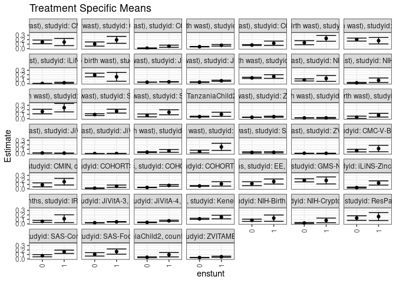

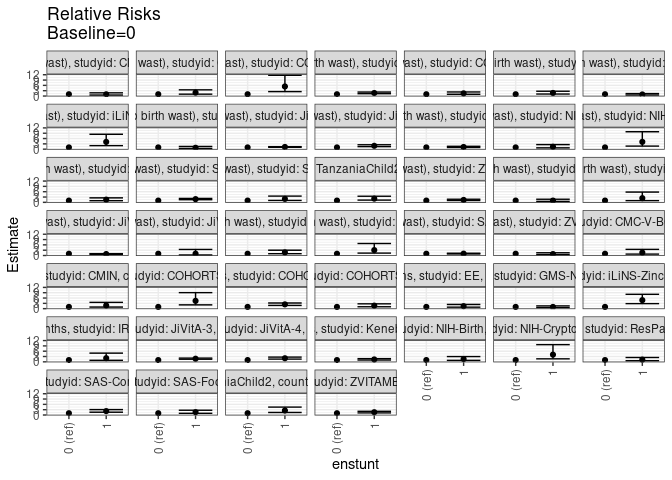

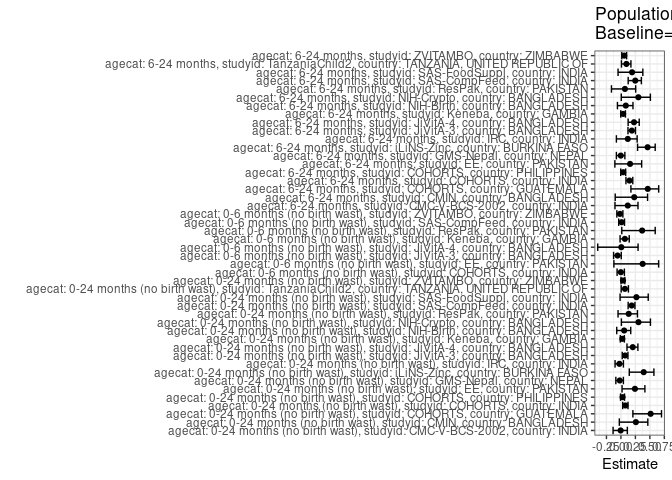

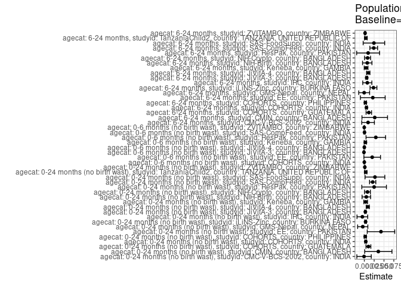

## Results Table

### Parameter: TSM

| agecat | studyid | country | intervention_level | baseline_level | estimate | ci_lower | ci_upper |
| --- | --- | --- | --- | --- | --- | --- | --- |
| 0-24 months (no birth wast) | CMC-V-BCS-2002 | INDIA | 0 | NA | 0.1501706 | 0.1092103 | 0.1911310 |
| 0-24 months (no birth wast) | CMC-V-BCS-2002 | INDIA | 1 | NA | 0.1466667 | 0.0664927 | 0.2268406 |
| 0-24 months (no birth wast) | CMIN | BANGLADESH | 0 | NA | 0.1024096 | 0.0562018 | 0.1486174 |
| 0-24 months (no birth wast) | CMIN | BANGLADESH | 1 | NA | 0.1960784 | 0.1188848 | 0.2732721 |
| 0-24 months (no birth wast) | COHORTS | GUATEMALA | 0 | NA | 0.0098717 | 0.0037812 | 0.0159621 |
| 0-24 months (no birth wast) | COHORTS | GUATEMALA | 1 | NA | 0.0532915 | 0.0286338 | 0.0779493 |
| 0-24 months (no birth wast) | COHORTS | INDIA | 0 | NA | 0.0435751 | 0.0385288 | 0.0486213 |
| 0-24 months (no birth wast) | COHORTS | INDIA | 1 | NA | 0.0743802 | 0.0567083 | 0.0920520 |
| 0-24 months (no birth wast) | COHORTS | PHILIPPINES | 0 | NA | 0.0801406 | 0.0701621 | 0.0901191 |
| 0-24 months (no birth wast) | COHORTS | PHILIPPINES | 1 | NA | 0.1206897 | 0.0722778 | 0.1691015 |
| 0-24 months (no birth wast) | EE | PAKISTAN | 0 | NA | 0.1327014 | 0.0868655 | 0.1785373 |
| 0-24 months (no birth wast) | EE | PAKISTAN | 1 | NA | 0.2289157 | 0.1649187 | 0.2929126 |
| 0-24 months (no birth wast) | GMS-Nepal | NEPAL | 0 | NA | 0.2025316 | 0.1690106 | 0.2360527 |
| 0-24 months (no birth wast) | GMS-Nepal | NEPAL | 1 | NA | 0.1775701 | 0.1051065 | 0.2500337 |
| 0-24 months (no birth wast) | iLiNS-Zinc | BURKINA FASO | 0 | NA | 0.0049060 | 0.0014445 | 0.0083675 |
| 0-24 months (no birth wast) | iLiNS-Zinc | BURKINA FASO | 1 | NA | 0.0201550 | 0.0093317 | 0.0309783 |
| 0-24 months (no birth wast) | IRC | INDIA | 0 | NA | 0.1932773 | 0.1522665 | 0.2342881 |
| 0-24 months (no birth wast) | IRC | INDIA | 1 | NA | 0.1538462 | 0.0556610 | 0.2520313 |
| 0-24 months (no birth wast) | JiVitA-3 | BANGLADESH | 0 | NA | 0.0331214 | 0.0301490 | 0.0360937 |
| 0-24 months (no birth wast) | JiVitA-3 | BANGLADESH | 1 | NA | 0.0413311 | 0.0365591 | 0.0461032 |
| 0-24 months (no birth wast) | JiVitA-4 | BANGLADESH | 0 | NA | 0.0342058 | 0.0276809 | 0.0407306 |
| 0-24 months (no birth wast) | JiVitA-4 | BANGLADESH | 1 | NA | 0.0650618 | 0.0527819 | 0.0773417 |
| 0-24 months (no birth wast) | Keneba | GAMBIA | 0 | NA | 0.1301961 | 0.1171325 | 0.1432597 |
| 0-24 months (no birth wast) | Keneba | GAMBIA | 1 | NA | 0.1603774 | 0.1200385 | 0.2007162 |
| 0-24 months (no birth wast) | NIH-Birth | BANGLADESH | 0 | NA | 0.0846457 | 0.0604201 | 0.1088713 |
| 0-24 months (no birth wast) | NIH-Birth | BANGLADESH | 1 | NA | 0.1170213 | 0.0519854 | 0.1820571 |
| 0-24 months (no birth wast) | NIH-Crypto | BANGLADESH | 0 | NA | 0.0184900 | 0.0081188 | 0.0288612 |
| 0-24 months (no birth wast) | NIH-Crypto | BANGLADESH | 1 | NA | 0.0761905 | 0.0254116 | 0.1269694 |
| 0-24 months (no birth wast) | ResPak | PAKISTAN | 0 | NA | 0.1608040 | 0.1096737 | 0.2119344 |
| 0-24 months (no birth wast) | ResPak | PAKISTAN | 1 | NA | 0.2469136 | 0.1528379 | 0.3409893 |

[output cut: 62 more lines]

### Parameter: E(Y)

| agecat | studyid | country | intervention_level | baseline_level | estimate | ci_lower | ci_upper |
| --- | --- | --- | --- | --- | --- | --- | --- |
| 0-24 months (no birth wast) | CMC-V-BCS-2002 | INDIA | NA | NA | 0.1494565 | 0.1129794 | 0.1859337 |
| 0-24 months (no birth wast) | CMIN | BANGLADESH | NA | NA | 0.1380597 | 0.0966822 | 0.1794372 |
| 0-24 months (no birth wast) | COHORTS | GUATEMALA | NA | NA | 0.0202703 | 0.0126995 | 0.0278411 |
| 0-24 months (no birth wast) | COHORTS | INDIA | NA | NA | 0.0472320 | 0.0423094 | 0.0521545 |
| 0-24 months (no birth wast) | COHORTS | PHILIPPINES | NA | NA | 0.0824776 | 0.0726632 | 0.0922921 |
| 0-24 months (no birth wast) | EE | PAKISTAN | NA | NA | 0.1750663 | 0.1366545 | 0.2134781 |
| 0-24 months (no birth wast) | GMS-Nepal | NEPAL | NA | NA | 0.1984848 | 0.1680322 | 0.2289375 |
| 0-24 months (no birth wast) | iLiNS-Zinc | BURKINA FASO | NA | NA | 0.0080880 | 0.0040249 | 0.0121511 |
| 0-24 months (no birth wast) | IRC | INDIA | NA | NA | 0.1882641 | 0.1503318 | 0.2261964 |
| 0-24 months (no birth wast) | JiVitA-3 | BANGLADESH | NA | NA | 0.0357345 | 0.0331597 | 0.0383093 |
| 0-24 months (no birth wast) | JiVitA-4 | BANGLADESH | NA | NA | 0.0429948 | 0.0372768 | 0.0487128 |
| 0-24 months (no birth wast) | Keneba | GAMBIA | NA | NA | 0.1335425 | 0.1210912 | 0.1459939 |
| 0-24 months (no birth wast) | NIH-Birth | BANGLADESH | NA | NA | 0.0897010 | 0.0668555 | 0.1125465 |
| 0-24 months (no birth wast) | NIH-Crypto | BANGLADESH | NA | NA | 0.0265252 | 0.0150478 | 0.0380026 |
| 0-24 months (no birth wast) | ResPak | PAKISTAN | NA | NA | 0.1857143 | 0.1400836 | 0.2313450 |
| 0-24 months (no birth wast) | SAS-CompFeed | INDIA | NA | NA | 0.1145140 | 0.0913579 | 0.1376700 |
| 0-24 months (no birth wast) | SAS-FoodSuppl | INDIA | NA | NA | 0.1007557 | 0.0711091 | 0.1304022 |
| 0-24 months (no birth wast) | TanzaniaChild2 | TANZANIA, UNITED REPUBLIC OF | NA | NA | 0.0507550 | 0.0419422 | 0.0595679 |
| 0-24 months (no birth wast) | ZVITAMBO | ZIMBABWE | NA | NA | 0.0350517 | 0.0319649 | 0.0381385 |
| 0-6 months (no birth wast) | COHORTS | INDIA | NA | NA | 0.0181260 | 0.0148850 | 0.0213669 |
| 0-6 months (no birth wast) | EE | PAKISTAN | NA | NA | 0.0533333 | 0.0305609 | 0.0761058 |
| 0-6 months (no birth wast) | JiVitA-3 | BANGLADESH | NA | NA | 0.0165815 | 0.0147663 | 0.0183968 |
| 0-6 months (no birth wast) | JiVitA-4 | BANGLADESH | NA | NA | 0.0042364 | 0.0017272 | 0.0067456 |
| 0-6 months (no birth wast) | Keneba | GAMBIA | NA | NA | 0.0391914 | 0.0314649 | 0.0469180 |
| 0-6 months (no birth wast) | ResPak | PAKISTAN | NA | NA | 0.0797101 | 0.0476990 | 0.1117213 |
| 0-6 months (no birth wast) | SAS-CompFeed | INDIA | NA | NA | 0.0312288 | 0.0186884 | 0.0437692 |
| 0-6 months (no birth wast) | ZVITAMBO | ZIMBABWE | NA | NA | 0.0098684 | 0.0081932 | 0.0115436 |
| 6-24 months | CMC-V-BCS-2002 | INDIA | NA | NA | 0.0804290 | 0.0527929 | 0.1080650 |
| 6-24 months | CMIN | BANGLADESH | NA | NA | 0.1150794 | 0.0756007 | 0.1545580 |
| 6-24 months | COHORTS | GUATEMALA | NA | NA | 0.0245902 | 0.0158961 | 0.0332842 |
| 6-24 months | COHORTS | INDIA | NA | NA | 0.0367382 | 0.0323123 | 0.0411641 |
| 6-24 months | COHORTS | PHILIPPINES | NA | NA | 0.0669277 | 0.0576848 | 0.0761707 |
| 6-24 months | EE | PAKISTAN | NA | NA | 0.1363636 | 0.1015372 | 0.1711900 |
| 6-24 months | GMS-Nepal | NEPAL | NA | NA | 0.1898305 | 0.1581595 | 0.2215015 |
| 6-24 months | iLiNS-Zinc | BURKINA FASO | NA | NA | 0.0505205 | 0.0383088 | 0.0627322 |
| 6-24 months | IRC | INDIA | NA | NA | 0.0634146 | 0.0397960 | 0.0870333 |
| 6-24 months | JiVitA-3 | BANGLADESH | NA | NA | 0.0319690 | 0.0290813 | 0.0348568 |
| 6-24 months | JiVitA-4 | BANGLADESH | NA | NA | 0.0440147 | 0.0381801 | 0.0498493 |
| 6-24 months | Keneba | GAMBIA | NA | NA | 0.1172389 | 0.1051866 | 0.1292911 |
| 6-24 months | NIH-Birth | BANGLADESH | NA | NA | 0.0885609 | 0.0646203 | 0.1125014 |
| 6-24 months | NIH-Crypto | BANGLADESH | NA | NA | 0.0273973 | 0.0155476 | 0.0392469 |
| 6-24 months | ResPak | PAKISTAN | NA | NA | 0.1398305 | 0.0954893 | 0.1841717 |
| 6-24 months | SAS-CompFeed | INDIA | NA | NA | 0.0964723 | 0.0729872 | 0.1199573 |
| 6-24 months | SAS-FoodSuppl | INDIA | NA | NA | 0.1268657 | 0.0942904 | 0.1594410 |
| 6-24 months | TanzaniaChild2 | TANZANIA, UNITED REPUBLIC OF | NA | NA | 0.0411298 | 0.0324631 | 0.0497965 |
| 6-24 months | ZVITAMBO | ZIMBABWE | NA | NA | 0.0329172 | 0.0295545 | 0.0362800 |

### Parameter: RR

| agecat | studyid | country | intervention_level | baseline_level | estimate | ci_lower | ci_upper |
| --- | --- | --- | --- | --- | --- | --- | --- |
| 0-24 months (no birth wast) | CMC-V-BCS-2002 | INDIA | 0 | 0 | 1.0000000 | 1.0000000 | 1.000000 |
| 0-24 months (no birth wast) | CMC-V-BCS-2002 | INDIA | 1 | 0 | 0.9766667 | 0.5301890 | 1.799128 |
| 0-24 months (no birth wast) | CMIN | BANGLADESH | 0 | 0 | 1.0000000 | 1.0000000 | 1.000000 |
| 0-24 months (no birth wast) | CMIN | BANGLADESH | 1 | 0 | 1.9146482 | 1.0520298 | 3.484576 |
| 0-24 months (no birth wast) | COHORTS | GUATEMALA | 0 | 0 | 1.0000000 | 1.0000000 | 1.000000 |
| 0-24 months (no birth wast) | COHORTS | GUATEMALA | 1 | 0 | 5.3984326 | 2.4965848 | 11.673176 |
| 0-24 months (no birth wast) | COHORTS | INDIA | 0 | 0 | 1.0000000 | 1.0000000 | 1.000000 |
| 0-24 months (no birth wast) | COHORTS | INDIA | 1 | 0 | 1.7069434 | 1.3104830 | 2.223345 |
| 0-24 months (no birth wast) | COHORTS | PHILIPPINES | 0 | 0 | 1.0000000 | 1.0000000 | 1.000000 |
| 0-24 months (no birth wast) | COHORTS | PHILIPPINES | 1 | 0 | 1.5059740 | 0.9894884 | 2.292051 |
| 0-24 months (no birth wast) | EE | PAKISTAN | 0 | 0 | 1.0000000 | 1.0000000 | 1.000000 |
| 0-24 months (no birth wast) | EE | PAKISTAN | 1 | 0 | 1.7250430 | 1.1061489 | 2.690211 |
| 0-24 months (no birth wast) | GMS-Nepal | NEPAL | 0 | 0 | 1.0000000 | 1.0000000 | 1.000000 |
| 0-24 months (no birth wast) | GMS-Nepal | NEPAL | 1 | 0 | 0.8767523 | 0.5644510 | 1.361845 |
| 0-24 months (no birth wast) | iLiNS-Zinc | BURKINA FASO | 0 | 0 | 1.0000000 | 1.0000000 | 1.000000 |
| 0-24 months (no birth wast) | iLiNS-Zinc | BURKINA FASO | 1 | 0 | 4.1082687 | 2.0078731 | 8.405846 |
| 0-24 months (no birth wast) | IRC | INDIA | 0 | 0 | 1.0000000 | 1.0000000 | 1.000000 |
| 0-24 months (no birth wast) | IRC | INDIA | 1 | 0 | 0.7959866 | 0.4062748 | 1.559522 |
| 0-24 months (no birth wast) | JiVitA-3 | BANGLADESH | 0 | 0 | 1.0000000 | 1.0000000 | 1.000000 |
| 0-24 months (no birth wast) | JiVitA-3 | BANGLADESH | 1 | 0 | 1.2478687 | 1.0808742 | 1.440664 |
| 0-24 months (no birth wast) | JiVitA-4 | BANGLADESH | 0 | 0 | 1.0000000 | 1.0000000 | 1.000000 |
| 0-24 months (no birth wast) | JiVitA-4 | BANGLADESH | 1 | 0 | 1.9020721 | 1.4469923 | 2.500275 |
| 0-24 months (no birth wast) | Keneba | GAMBIA | 0 | 0 | 1.0000000 | 1.0000000 | 1.000000 |
| 0-24 months (no birth wast) | Keneba | GAMBIA | 1 | 0 | 1.2318140 | 0.9395900 | 1.614923 |
| 0-24 months (no birth wast) | NIH-Birth | BANGLADESH | 0 | 0 | 1.0000000 | 1.0000000 | 1.000000 |
| 0-24 months (no birth wast) | NIH-Birth | BANGLADESH | 1 | 0 | 1.3824839 | 0.7398983 | 2.583141 |
| 0-24 months (no birth wast) | NIH-Crypto | BANGLADESH | 0 | 0 | 1.0000000 | 1.0000000 | 1.000000 |
| 0-24 months (no birth wast) | NIH-Crypto | BANGLADESH | 1 | 0 | 4.1206349 | 1.7244576 | 9.846361 |
| 0-24 months (no birth wast) | ResPak | PAKISTAN | 0 | 0 | 1.0000000 | 1.0000000 | 1.000000 |
| 0-24 months (no birth wast) | ResPak | PAKISTAN | 1 | 0 | 1.5354938 | 0.9348186 | 2.522138 |

[output cut: 62 more lines]

### Parameter: PAR

| agecat | studyid | country | intervention_level | baseline_level | estimate | ci_lower | ci_upper |
| --- | --- | --- | --- | --- | --- | --- | --- |
| 0-24 months (no birth wast) | CMC-V-BCS-2002 | INDIA | 0 | NA | -0.0007141 | -0.0190634 | 0.0176352 |
| 0-24 months (no birth wast) | CMIN | BANGLADESH | 0 | NA | 0.0356501 | 0.0009772 | 0.0703230 |
| 0-24 months (no birth wast) | COHORTS | GUATEMALA | 0 | NA | 0.0103986 | 0.0042349 | 0.0165623 |
| 0-24 months (no birth wast) | COHORTS | INDIA | 0 | NA | 0.0036569 | 0.0014630 | 0.0058508 |
| 0-24 months (no birth wast) | COHORTS | PHILIPPINES | 0 | NA | 0.0023370 | -0.0005317 | 0.0052058 |
| 0-24 months (no birth wast) | EE | PAKISTAN | 0 | NA | 0.0423649 | 0.0073693 | 0.0773605 |
| 0-24 months (no birth wast) | GMS-Nepal | NEPAL | 0 | NA | -0.0040468 | -0.0170098 | 0.0089162 |
| 0-24 months (no birth wast) | iLiNS-Zinc | BURKINA FASO | 0 | NA | 0.0031820 | 0.0013350 | 0.0050291 |
| 0-24 months (no birth wast) | IRC | INDIA | 0 | NA | -0.0050133 | -0.0186015 | 0.0085750 |
| 0-24 months (no birth wast) | JiVitA-3 | BANGLADESH | 0 | NA | 0.0026131 | 0.0008475 | 0.0043788 |
| 0-24 months (no birth wast) | JiVitA-4 | BANGLADESH | 0 | NA | 0.0087891 | 0.0047538 | 0.0128243 |
| 0-24 months (no birth wast) | Keneba | GAMBIA | 0 | NA | 0.0033465 | -0.0013677 | 0.0080607 |
| 0-24 months (no birth wast) | NIH-Birth | BANGLADESH | 0 | NA | 0.0050553 | -0.0058221 | 0.0159327 |
| 0-24 months (no birth wast) | NIH-Crypto | BANGLADESH | 0 | NA | 0.0080352 | 0.0006782 | 0.0153922 |
| 0-24 months (no birth wast) | ResPak | PAKISTAN | 0 | NA | 0.0249103 | -0.0064013 | 0.0562218 |
| 0-24 months (no birth wast) | SAS-CompFeed | INDIA | 0 | NA | 0.0212545 | 0.0133375 | 0.0291715 |
| 0-24 months (no birth wast) | SAS-FoodSuppl | INDIA | 0 | NA | 0.0269852 | 0.0018512 | 0.0521191 |
| 0-24 months (no birth wast) | TanzaniaChild2 | TANZANIA, UNITED REPUBLIC OF | 0 | NA | 0.0035003 | 0.0002784 | 0.0067222 |
| 0-24 months (no birth wast) | ZVITAMBO | ZIMBABWE | 0 | NA | 0.0012365 | 0.0000650 | 0.0024079 |
| 0-6 months (no birth wast) | COHORTS | INDIA | 0 | NA | -0.0000213 | -0.0011631 | 0.0011205 |
| 0-6 months (no birth wast) | EE | PAKISTAN | 0 | NA | 0.0200000 | -0.0011581 | 0.0411581 |
| 0-6 months (no birth wast) | JiVitA-3 | BANGLADESH | 0 | NA | -0.0009702 | -0.0020729 | 0.0001326 |
| 0-6 months (no birth wast) | JiVitA-4 | BANGLADESH | 0 | NA | 0.0000300 | -0.0014141 | 0.0014742 |
| 0-6 months (no birth wast) | Keneba | GAMBIA | 0 | NA | 0.0026617 | -0.0004787 | 0.0058022 |
| 0-6 months (no birth wast) | ResPak | PAKISTAN | 0 | NA | 0.0292051 | 0.0043308 | 0.0540794 |
| 0-6 months (no birth wast) | SAS-CompFeed | INDIA | 0 | NA | 0.0004165 | -0.0011312 | 0.0019641 |
| 0-6 months (no birth wast) | ZVITAMBO | ZIMBABWE | 0 | NA | -0.0001681 | -0.0006830 | 0.0003468 |
| 6-24 months | CMC-V-BCS-2002 | INDIA | 0 | NA | 0.0094830 | -0.0066466 | 0.0256126 |
| 6-24 months | CMIN | BANGLADESH | 0 | NA | 0.0264718 | -0.0060540 | 0.0589976 |
| 6-24 months | COHORTS | GUATEMALA | 0 | NA | 0.0114034 | 0.0044357 | 0.0183710 |
| 6-24 months | COHORTS | INDIA | 0 | NA | 0.0054319 | 0.0031706 | 0.0076931 |
| 6-24 months | COHORTS | PHILIPPINES | 0 | NA | 0.0026798 | -0.0001928 | 0.0055524 |
| 6-24 months | EE | PAKISTAN | 0 | NA | 0.0215311 | -0.0099727 | 0.0530349 |
| 6-24 months | GMS-Nepal | NEPAL | 0 | NA | -0.0004529 | -0.0143615 | 0.0134557 |
| 6-24 months | iLiNS-Zinc | BURKINA FASO | 0 | NA | 0.0232801 | 0.0145903 | 0.0319699 |
| 6-24 months | IRC | INDIA | 0 | NA | 0.0075487 | -0.0040444 | 0.0191418 |
| 6-24 months | JiVitA-3 | BANGLADESH | 0 | NA | 0.0060545 | 0.0038844 | 0.0082246 |
| 6-24 months | JiVitA-4 | BANGLADESH | 0 | NA | 0.0099590 | 0.0056637 | 0.0142544 |
| 6-24 months | Keneba | GAMBIA | 0 | NA | 0.0044817 | -0.0002766 | 0.0092399 |
| 6-24 months | NIH-Birth | BANGLADESH | 0 | NA | 0.0074205 | -0.0045625 | 0.0194035 |
| 6-24 months | NIH-Crypto | BANGLADESH | 0 | NA | 0.0082585 | 0.0006596 | 0.0158574 |
| 6-24 months | ResPak | PAKISTAN | 0 | NA | 0.0096530 | -0.0194846 | 0.0387906 |
| 6-24 months | SAS-CompFeed | INDIA | 0 | NA | 0.0239077 | 0.0141026 | 0.0337127 |
| 6-24 months | SAS-FoodSuppl | INDIA | 0 | NA | 0.0244067 | -0.0029913 | 0.0518046 |
| 6-24 months | TanzaniaChild2 | TANZANIA, UNITED REPUBLIC OF | 0 | NA | 0.0038958 | 0.0004534 | 0.0073381 |
| 6-24 months | ZVITAMBO | ZIMBABWE | 0 | NA | 0.0018967 | 0.0005205 | 0.0032728 |

### Parameter: PAF

| agecat | studyid | country | intervention_level | baseline_level | estimate | ci_lower | ci_upper |
| --- | --- | --- | --- | --- | --- | --- | --- |
| 0-24 months (no birth wast) | CMC-V-BCS-2002 | INDIA | 0 | NA | -0.0047782 | -0.1353636 | 0.1107878 |
| 0-24 months (no birth wast) | CMIN | BANGLADESH | 0 | NA | 0.2582221 | -0.0277581 | 0.4646265 |
| 0-24 months (no birth wast) | COHORTS | GUATEMALA | 0 | NA | 0.5129977 | 0.2066162 | 0.7010637 |
| 0-24 months (no birth wast) | COHORTS | INDIA | 0 | NA | 0.0774241 | 0.0304594 | 0.1221138 |
| 0-24 months (no birth wast) | COHORTS | PHILIPPINES | 0 | NA | 0.0283355 | -0.0069366 | 0.0623721 |
| 0-24 months (no birth wast) | EE | PAKISTAN | 0 | NA | 0.2419934 | 0.0195399 | 0.4139751 |
| 0-24 months (no birth wast) | GMS-Nepal | NEPAL | 0 | NA | -0.0203884 | -0.0877942 | 0.0428404 |
| 0-24 months (no birth wast) | iLiNS-Zinc | BURKINA FASO | 0 | NA | 0.3934260 | 0.1446156 | 0.5698635 |
| 0-24 months (no birth wast) | IRC | INDIA | 0 | NA | -0.0266288 | -0.1012912 | 0.0429717 |
| 0-24 months (no birth wast) | JiVitA-3 | BANGLADESH | 0 | NA | 0.0731257 | 0.0226364 | 0.1210067 |
| 0-24 months (no birth wast) | JiVitA-4 | BANGLADESH | 0 | NA | 0.2044214 | 0.1046227 | 0.2930965 |
| 0-24 months (no birth wast) | Keneba | GAMBIA | 0 | NA | 0.0250591 | -0.0108327 | 0.0596766 |
| 0-24 months (no birth wast) | NIH-Birth | BANGLADESH | 0 | NA | 0.0563575 | -0.0722532 | 0.1695422 |
| 0-24 months (no birth wast) | NIH-Crypto | BANGLADESH | 0 | NA | 0.3029276 | 0.0082660 | 0.5100400 |
| 0-24 months (no birth wast) | ResPak | PAKISTAN | 0 | NA | 0.1341322 | -0.0496239 | 0.2857184 |
| 0-24 months (no birth wast) | SAS-CompFeed | INDIA | 0 | NA | 0.1856063 | 0.1247869 | 0.2421993 |
| 0-24 months (no birth wast) | SAS-FoodSuppl | INDIA | 0 | NA | 0.2678279 | -0.0145481 | 0.4716110 |
| 0-24 months (no birth wast) | TanzaniaChild2 | TANZANIA, UNITED REPUBLIC OF | 0 | NA | 0.0689647 | 0.0043674 | 0.1293710 |
| 0-24 months (no birth wast) | ZVITAMBO | ZIMBABWE | 0 | NA | 0.0352752 | 0.0014078 | 0.0679940 |
| 0-6 months (no birth wast) | COHORTS | INDIA | 0 | NA | -0.0011747 | -0.0661910 | 0.0598770 |
| 0-6 months (no birth wast) | EE | PAKISTAN | 0 | NA | 0.3750000 | -0.1215451 | 0.6517082 |
| 0-6 months (no birth wast) | JiVitA-3 | BANGLADESH | 0 | NA | -0.0585090 | -0.1267797 | 0.0056252 |
| 0-6 months (no birth wast) | JiVitA-4 | BANGLADESH | 0 | NA | 0.0070908 | -0.4007295 | 0.2961748 |
| 0-6 months (no birth wast) | Keneba | GAMBIA | 0 | NA | 0.0679164 | -0.0146272 | 0.1437447 |
| 0-6 months (no birth wast) | ResPak | PAKISTAN | 0 | NA | 0.3663912 | 0.0151219 | 0.5923758 |
| 0-6 months (no birth wast) | SAS-CompFeed | INDIA | 0 | NA | 0.0133358 | -0.0381419 | 0.0622608 |
| 0-6 months (no birth wast) | ZVITAMBO | ZIMBABWE | 0 | NA | -0.0170316 | -0.0704882 | 0.0337555 |
| 6-24 months | CMC-V-BCS-2002 | INDIA | 0 | NA | 0.1179054 | -0.1028925 | 0.2944998 |
| 6-24 months | CMIN | BANGLADESH | 0 | NA | 0.2300306 | -0.0986101 | 0.4603609 |
| 6-24 months | COHORTS | GUATEMALA | 0 | NA | 0.4637363 | 0.1724366 | 0.6524994 |
| 6-24 months | COHORTS | INDIA | 0 | NA | 0.1478536 | 0.0866650 | 0.2049429 |
| 6-24 months | COHORTS | PHILIPPINES | 0 | NA | 0.0400404 | -0.0035321 | 0.0817210 |
| 6-24 months | EE | PAKISTAN | 0 | NA | 0.1578947 | -0.1045195 | 0.3579640 |
| 6-24 months | GMS-Nepal | NEPAL | 0 | NA | -0.0023858 | -0.0783980 | 0.0682686 |
| 6-24 months | iLiNS-Zinc | BURKINA FASO | 0 | NA | 0.4608047 | 0.2875717 | 0.5919145 |
| 6-24 months | IRC | INDIA | 0 | NA | 0.1190374 | -0.0782406 | 0.2802208 |
| 6-24 months | JiVitA-3 | BANGLADESH | 0 | NA | 0.1893867 | 0.1219233 | 0.2516669 |
| 6-24 months | JiVitA-4 | BANGLADESH | 0 | NA | 0.2262653 | 0.1244886 | 0.3162105 |
| 6-24 months | Keneba | GAMBIA | 0 | NA | 0.0382267 | -0.0030795 | 0.0778320 |
| 6-24 months | NIH-Birth | BANGLADESH | 0 | NA | 0.0837902 | -0.0602044 | 0.2082278 |
| 6-24 months | NIH-Crypto | BANGLADESH | 0 | NA | 0.3014354 | 0.0063132 | 0.5089071 |
| 6-24 months | ResPak | PAKISTAN | 0 | NA | 0.0690335 | -0.1635020 | 0.2550949 |
| 6-24 months | SAS-CompFeed | INDIA | 0 | NA | 0.2478191 | 0.1253667 | 0.3531276 |
| 6-24 months | SAS-FoodSuppl | INDIA | 0 | NA | 0.1923819 | -0.0495168 | 0.3785264 |
| 6-24 months | TanzaniaChild2 | TANZANIA, UNITED REPUBLIC OF | 0 | NA | 0.0947193 | 0.0094706 | 0.1726312 |
| 6-24 months | ZVITAMBO | ZIMBABWE | 0 | NA | 0.0576193 | 0.0152794 | 0.0981387 |